# **Red Wine Exploration by Dominic Del Rosario**

This report explores a dataset containing quality (which is an expert grading from 0 to 10) and attributes for approximately 1600 Red wines.

### Univariate Plots Section

```
## 'data.frame':    1599 obs. of  12 variables:
##  $ fixed.acidity       : num  7.4 7.8 7.8 11.2 7.4 7.4 7.9 7.3 7.8 7.5 ...
##  $ volatile.acidity    : num  0.7 0.88 0.76 0.28 0.7 0.66 0.6 0.65 0.58 0.5 ...
##  $ citric.acid         : num  0 0 0.04 0.56 0 0 0.06 0 0.02 0.36 ...
##  $ residual.sugar      : num  1.9 2.6 2.3 1.9 1.9 1.8 1.6 1.2 2 6.1 ...
##  $ chlorides           : num  0.076 0.098 0.092 0.075 0.076 0.075 0.069 0.065 0.073 0.071 ...
##  $ free.sulfur.dioxide : num  11 25 15 17 11 13 15 15 9 17 ...
##  $ total.sulfur.dioxide: num  34 67 54 60 34 40 59 21 18 102 ...
##  $ density             : num  0.998 0.997 0.997 0.998 0.998 ...
##  $ pH                  : num  3.51 3.2 3.26 3.16 3.51 3.51 3.3 3.39 3.36 3.35 ...
##  $ sulphates           : num  0.56 0.68 0.65 0.58 0.56 0.56 0.46 0.47 0.57 0.8 ...
##  $ alcohol             : num  9.4 9.8 9.8 9.8 9.4 9.4 9.4 10 9.5 10.5 ...
##  $ quality             : int  5 5 5 6 5 5 5 7 7 5 ...
```

```
##  fixed.acidity   volatile.acidity  citric.acid    residual.sugar
##  Min.   : 4.60   Min.   :0.1200   Min.   :0.000   Min.   : 0.900
##  1st Qu.: 7.10   1st Qu.:0.3900   1st Qu.:0.090   1st Qu.: 1.900
##  Median : 7.90   Median :0.5200   Median :0.260   Median : 2.200
##  Mean   : 8.32   Mean   :0.5278   Mean   :0.271   Mean   : 2.539
##  3rd Qu.: 9.20   3rd Qu.:0.6400   3rd Qu.:0.420   3rd Qu.: 2.600
##  Max.   :15.90   Max.   :1.5800   Max.   :1.000   Max.   :15.500
##    chlorides       free.sulfur.dioxide total.sulfur.dioxide
##  Min.   :0.01200   Min.   : 1.00       Min.   :  6.00
##  1st Qu.:0.07000   1st Qu.: 7.00       1st Qu.: 22.00
##  Median :0.07900   Median :14.00       Median : 38.00
##  Mean   :0.08747   Mean   :15.87       Mean   : 46.47
##  3rd Qu.:0.09000   3rd Qu.:21.00       3rd Qu.: 62.00
##  Max.   :0.61100   Max.   :72.00       Max.   :289.00
##     density             pH          sulphates         alcohol
##  Min.   :0.9901   Min.   :2.740   Min.   :0.3300   Min.   : 8.40
##  1st Qu.:0.9956   1st Qu.:3.210   1st Qu.:0.5500   1st Qu.: 9.50
##  Median :0.9968   Median :3.310   Median :0.6200   Median :10.20
##  Mean   :0.9967   Mean   :3.311   Mean   :0.6581   Mean   :10.42
##  3rd Qu.:0.9978   3rd Qu.:3.400   3rd Qu.:0.7300   3rd Qu.:11.10
##  Max.   :1.0037   Max.   :4.010   Max.   :2.0000   Max.   :14.90
##     quality
##  Min.   :3.000
##  1st Qu.:5.000
##  Median :6.000
##  Mean   :5.636
##  3rd Qu.:6.000
##  Max.   :8.000
```

```
##  [1] "fixed.acidity"        "volatile.acidity"     "citric.acid"
##  [4] "residual.sugar"       "chlorides"            "free.sulfur.dioxide"
##  [7] "total.sulfur.dioxide" "density"              "pH"
## [10] "sulphates"            "alcohol"              "quality"
```

Our dataset consists of twelve variables, with almost 1600 observations.

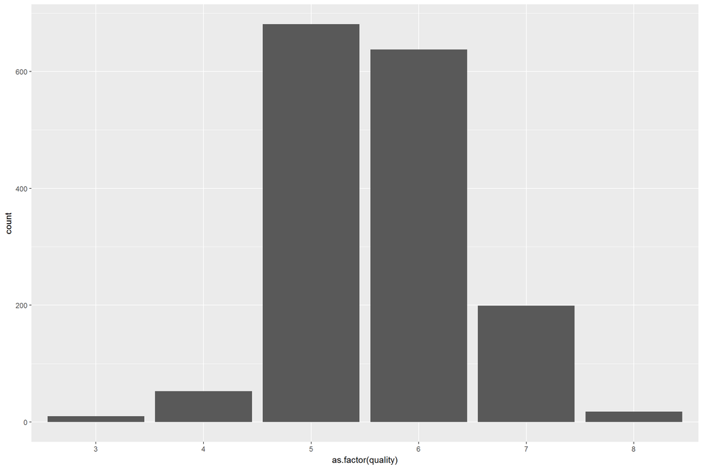

```
##    Min. 1st Qu.  Median    Mean 3rd Qu.    Max.
##   3.000   5.000   6.000   5.636   6.000   8.000
```

The mean quality wine score is 5.63 and the median is 6. It can been seen from the graph that most of the quality wine scores are either 5 or 6.

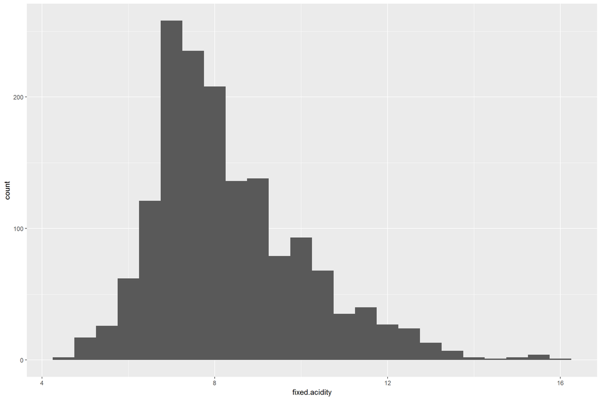

```
##    Min. 1st Qu.  Median    Mean 3rd Qu.    Max.
##    4.60    7.10    7.90    8.32    9.20   15.90
```

The median of fixed acidity is 7.9 and mean is 8.3 and much of the distribution is in that area.

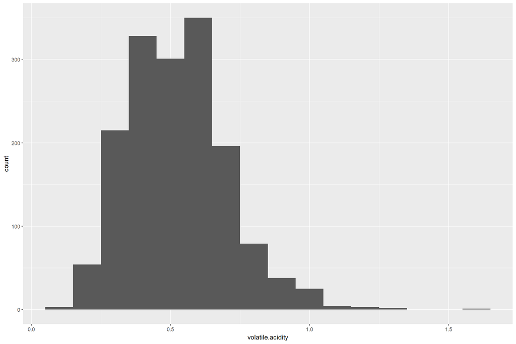

```
##    Min. 1st Qu.  Median    Mean 3rd Qu.    Max.
##  0.1200  0.3900  0.5200  0.5278  0.6400  1.5800
```

Volatile acidity is one of the variables that contribute to taste. The median and mean are around 0.5. From the dataset description, it says too much volatile acidity causes a vinegar taste. We will see the effect of that in a later graph.

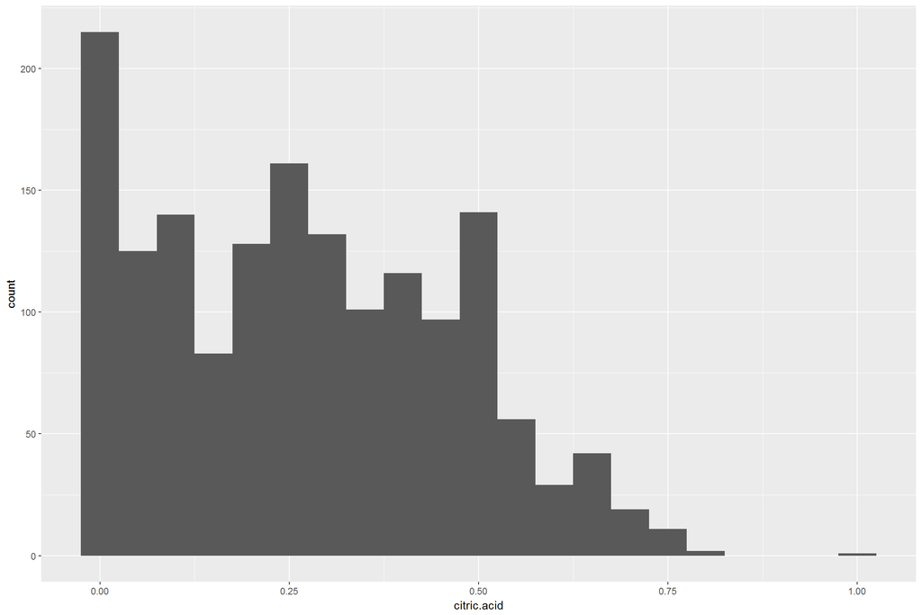

```
##    Min. 1st Qu.  Median    Mean 3rd Qu.    Max.
##   0.000   0.090   0.260   0.271   0.420   1.000
```

Citric acid is another one of the variables that contribute to taste. However, from the definition of the dataset, it’s often found in small quantities. It seems to make sense that the distribution be right skewed.

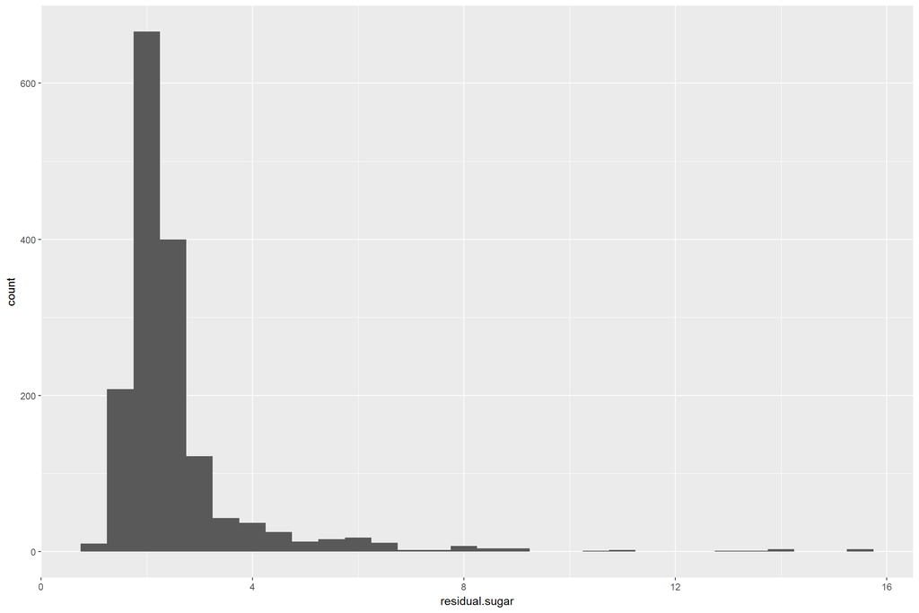

```
##    Min. 1st Qu.  Median    Mean 3rd Qu.    Max.
##   0.900   1.900   2.200   2.539   2.600  15.500
```

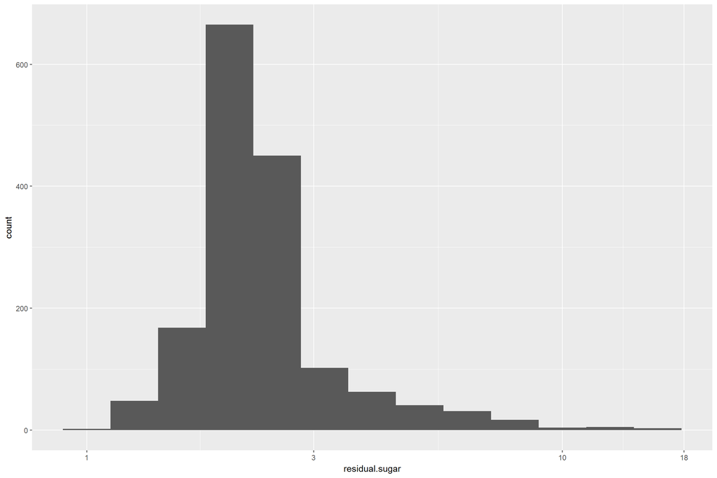

The median of residual sugar is 2.2 and the mean is 2.5 and much of the distribution is in that area. Taking the log of residual sugar produces a more normal distribution with a peak of around 2.2 and 2.5.

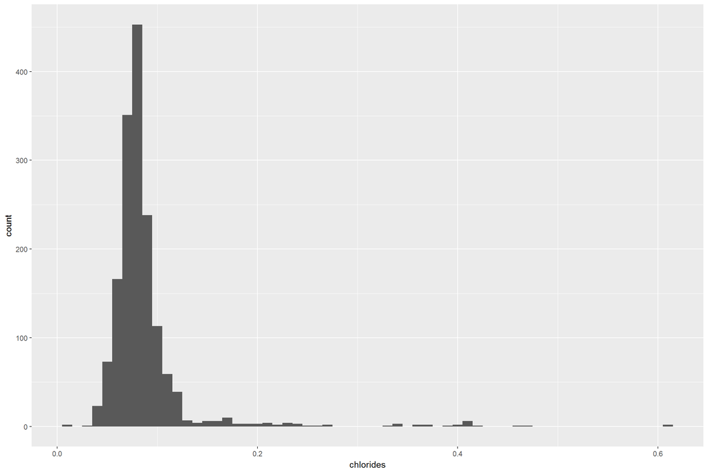

```
##    Min. 1st Qu.  Median    Mean 3rd Qu.    Max.
## 0.01200 0.07000 0.07900 0.08747 0.09000 0.61100
```

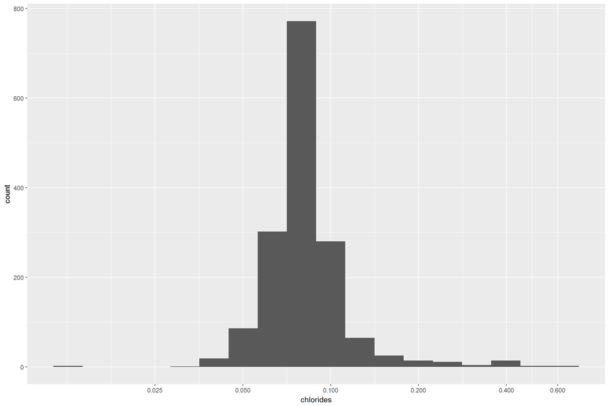

Chlorides is the amount of salt in the wine. The median is 0.079 and mean is 0.087. Taking the log of chlorides produces a more normal distribution with a peak of around 0.08.

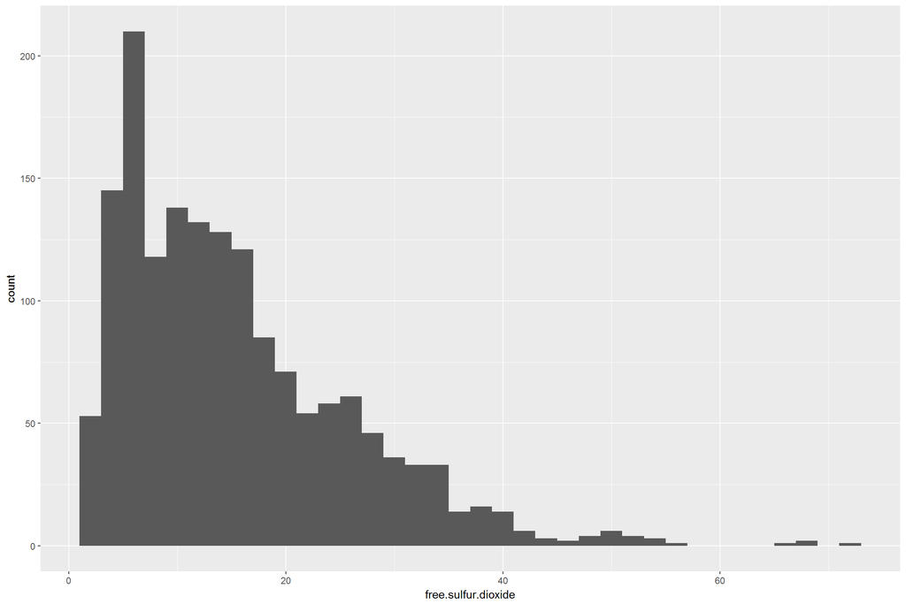

```
##    Min. 1st Qu.  Median    Mean 3rd Qu.    Max.
##    1.00    7.00   14.00   15.87   21.00   72.00
```

The median of free sulfur dioxide is 14 and the mean is 15.9 and much of the distribution is in that area. This makes sense to be right skewed as the amount added to prevent microbial growth and oxidation would be lower.

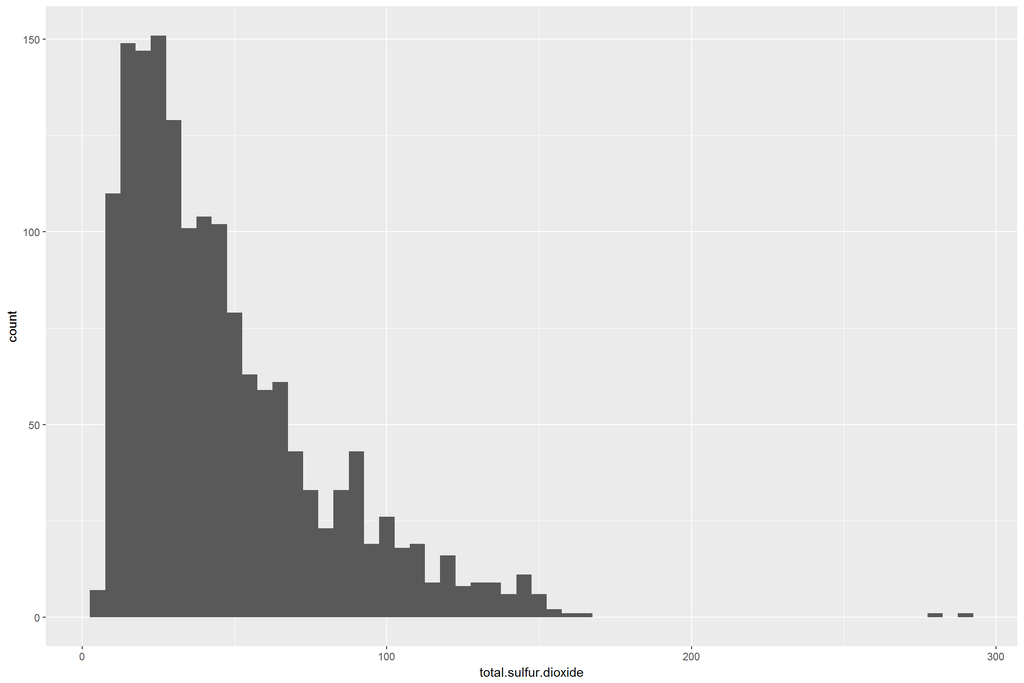

```
##    Min. 1st Qu.  Median    Mean 3rd Qu.    Max.
##    6.00   22.00   38.00   46.47   62.00  289.00
```

According to the dataset, total sulfur dioxide is mostly undetectable in wine. Similar to free sulfur dioxide, the distribution of total sulfur dioxide makes sense to be right skewed since a lot of the values would be on the lower end.

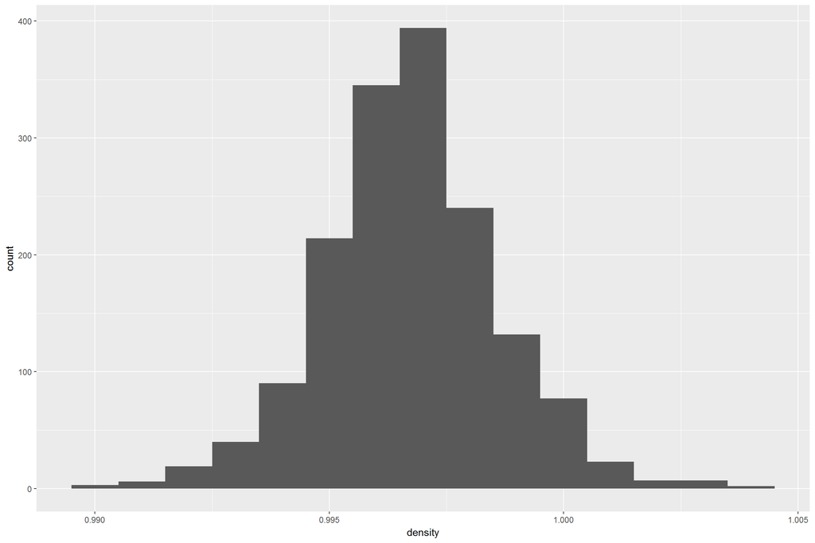

```
##    Min. 1st Qu.  Median    Mean 3rd Qu.    Max.
##  0.9901  0.9956  0.9968  0.9967  0.9978  1.0040
```

The median and mean of density is 0.997 the distribution appears normal.

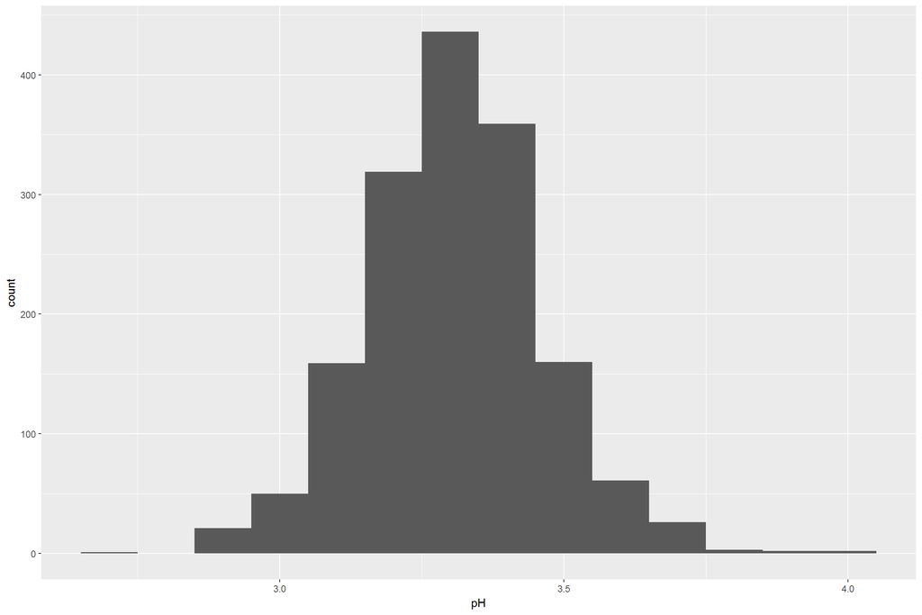

```
##    Min. 1st Qu.  Median    Mean 3rd Qu.    Max.
##   2.740   3.210   3.310   3.311   3.400   4.010
```

The mean & median of PH are 3.3. Since this contributes to the acidity or base of the wine, it makes sense to be normally distributed.

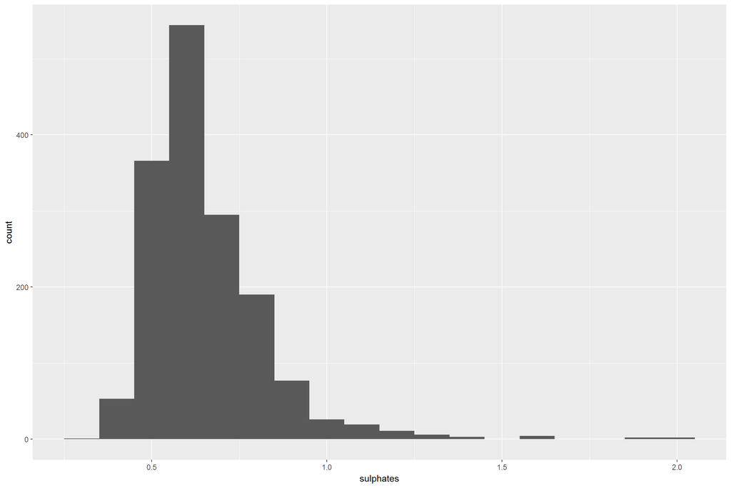

```
##    Min. 1st Qu.  Median    Mean 3rd Qu.    Max.
##  0.3300  0.5500  0.6200  0.6581  0.7300  2.0000
```

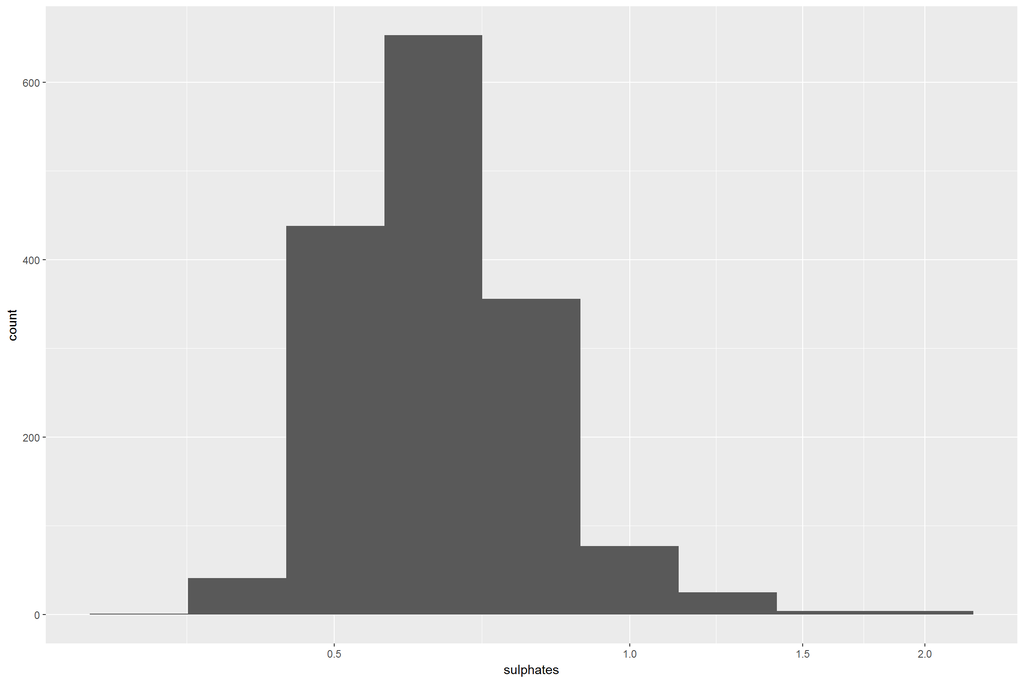

The median of residual is 0.62 and the mean is 0.65 and much of the distribution is in that area. Taking the log of sulphates, we see a more normal distribution and peak of 0.6.

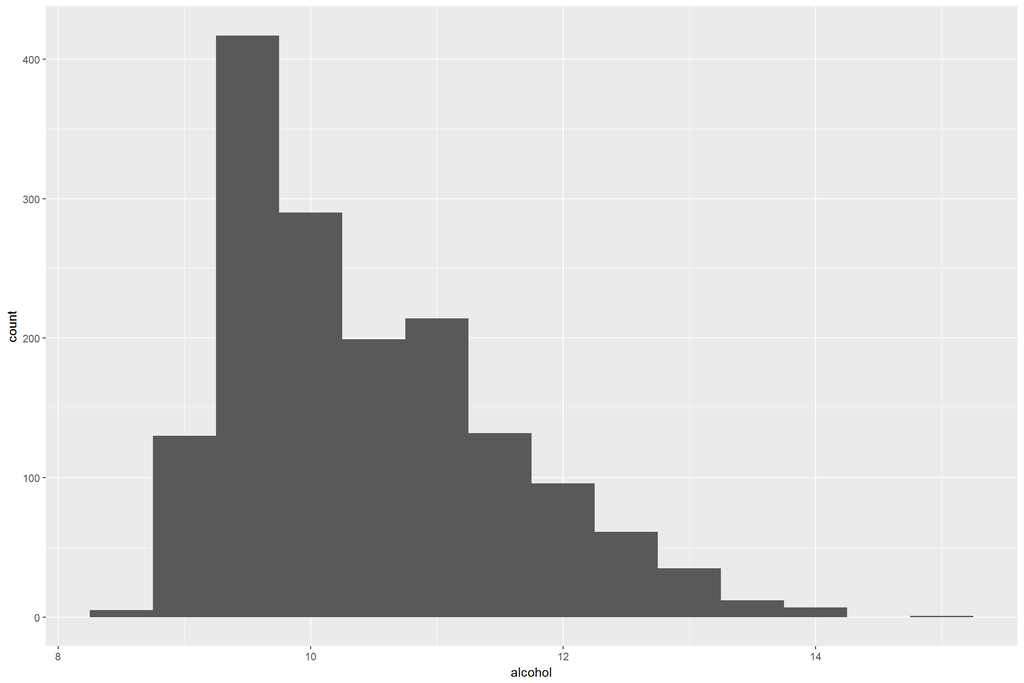

```
##    Min. 1st Qu.  Median    Mean 3rd Qu.    Max.
##    8.40    9.50   10.20   10.42   11.10   14.90
```

The mean percentage of alcohol is 10.4 and median is 10.2. We will see in the next section the relationship between alcohol and quality (score).

### Univariate Analysis

#### Structure of Dataset

There are 1,599 red wines in the dataset with 12 features (fixed acidity, volatile acidity, citric acid, residual sugar, chlorides, free sulfur dioxide, total sulfur dioxide, density, pH, sulphates, alcohol and quality).

All of the variables are input variables (based on physiochemical tests) except quality which is an output variable. Quality is a score between 0 (very bad) and 10 (very excellent) based on sensory data. All of the input variables are numeric.

Other observations:

Most of the quality wine scores were either 5 or 6.

The amount of residual sugar had a median of 2.2. This variable would obviously determine how sweet a wine tastes.

The median of free sulfur dioxide is 14. I eventually drop the residual sugar and free sulfur dioxide variables due to their lowest correlation to quality score.

#### Main Feature(s) of interest in Dataset

The only output variable is quality wine score from experts. The variables of interest that experts may be able to grade on would be variables that contribute to taste or smell. Those include chlorides, pH, total sulfur dioxide, volatile acidity and citric acid.

#### Other feature(s) that may help in investigation

We can investigate other variables like fixed acidity, density, sulphates and alcohol to see how related they are to quality wine score.

#### New variables

For the project, I did not create any new variables to examine. The dataset had twelve variables and I dropped two variables for the rest of the exploration.

#### Unusual distributions

Citric acid had a right skewed distribution but it seemed to make sense since the amount of citric acid is very small or zero. Total sulfur dioxide also had a right skewed distribution. By definition, very little is put in wine and therefore undetectable for the most part.

## Bivariate Plots Section

To simply the correlation matrix to a 10 by 10 matrix, I dropped the variables residual.sugar and free.sulfur.dioxide due to having the lowest correlation to quality at 0.014 & -0.051 respectively.

```
##
##  Pearson's product-moment correlation
##
## data:  redwines$residual.sugar and redwines$quality
## t = 0.5488, df = 1597, p-value = 0.5832
## alternative hypothesis: true correlation is not equal to 0
## 95 percent confidence interval:
##  -0.03531327  0.06271056
## sample estimates:
##        cor
## 0.01373164
```

```
##
##  Pearson's product-moment correlation
##
## data:  redwines$free.sulfur.dioxide and redwines$quality
## t = -2.0269, df = 1597, p-value = 0.04283
## alternative hypothesis: true correlation is not equal to 0
## 95 percent confidence interval:
##  -0.099430290 -0.001638987
## sample estimates:
##         cor
## -0.05065606
```

**Correlation Matrix**

```
##                      fixed.acidity volatile.acidity citric.acid chlorides
## fixed.acidity                1.000           -0.256       0.672     0.094
## volatile.acidity            -0.256            1.000      -0.552     0.061
## citric.acid                  0.672           -0.552       1.000     0.204
## chlorides                    0.094            0.061       0.204     1.000
## total.sulfur.dioxide        -0.113            0.076       0.036     0.047
## density                      0.668            0.022       0.365     0.201
## pH                          -0.683            0.235      -0.542    -0.265
## sulphates                    0.183           -0.261       0.313     0.371
## alcohol                     -0.062           -0.202       0.110    -0.221
## quality                      0.124           -0.391       0.226    -0.129
##                      total.sulfur.dioxide density     pH sulphates alcohol
## fixed.acidity                      -0.113   0.668 -0.683     0.183  -0.062
## volatile.acidity                    0.076   0.022  0.235    -0.261  -0.202
## citric.acid                         0.036   0.365 -0.542     0.313   0.110
## chlorides                           0.047   0.201 -0.265     0.371  -0.221
## total.sulfur.dioxide                1.000   0.071 -0.066     0.043  -0.206
## density                             0.071   1.000 -0.342     0.149  -0.496
## pH                                 -0.066  -0.342  1.000    -0.197   0.206
## sulphates                           0.043   0.149 -0.197     1.000   0.094
## alcohol                            -0.206  -0.496  0.206     0.094   1.000
## quality                            -0.185  -0.175 -0.058     0.251   0.476
##                      quality
## fixed.acidity          0.124
## volatile.acidity      -0.391
## citric.acid            0.226
## chlorides             -0.129
## total.sulfur.dioxide  -0.185
## density               -0.175
## pH                    -0.058
## sulphates              0.251
## alcohol                0.476
## quality                1.000
```

Additionally, looking at the correlation of quality versus the other variables, the highest correlation we see is with alcohol but only moderate at 0.476. The only other meaningful correlation would be with volatile acidity at -0.391. By definition, too much volatile acidity would result in a vinegar taste and we will see that in a forthcoming graph.

### Bivariate Analysis

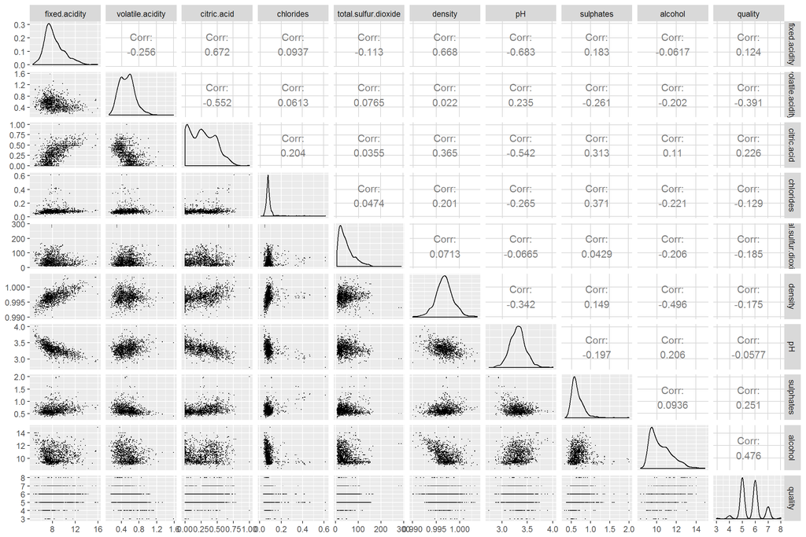

Now, I am taking the six most correlated variables to quality (alcohol, volatile.acidity, sulphates, citric.acid, total.sulfur.dioxide and density). Again, only alcohol and volatile acidity are meaningful to moderately correlated from the correlation matrix.

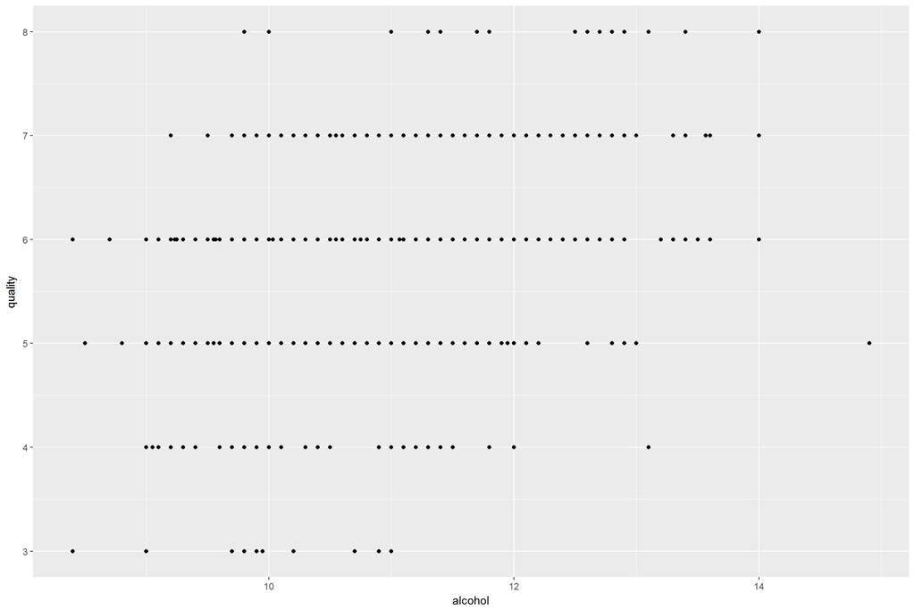

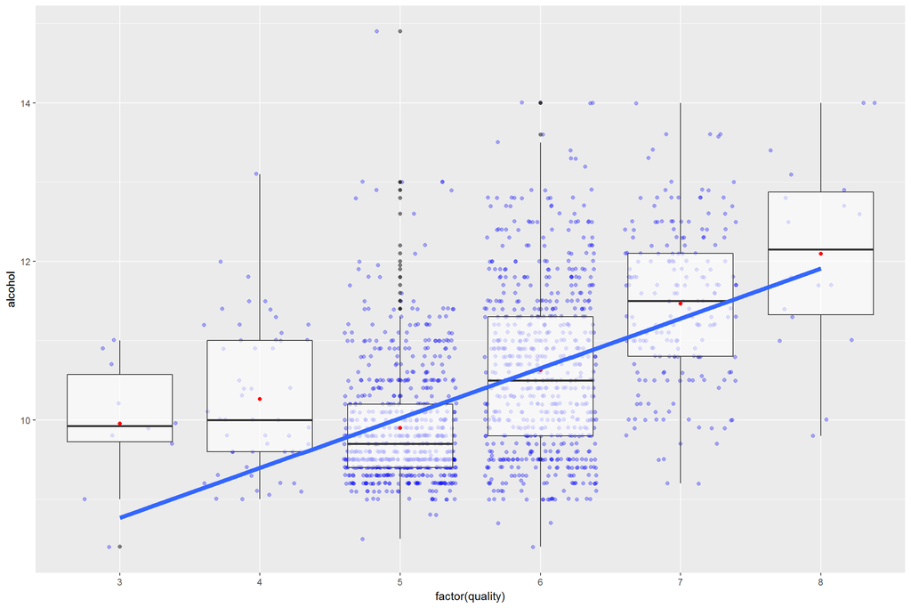

The scatterplot of quality versus alcohol was a little hard to read. The second gave a better picture. Because most of the quality wine scores are either 5 and 6 and the alcohol percentages are around 10, we see a lot of the distribution in that area. There seems to be a positive linear relationship between alcohol and quality.

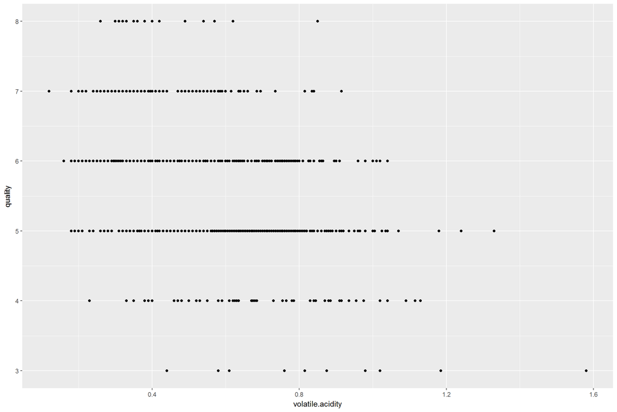

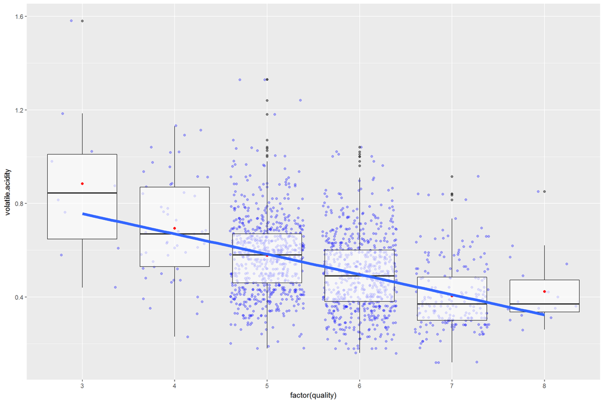

Again, the scatterplot of quality versus volatile acidity was hard to read. The second was better. Because most of the wine quality scores are either 5 or 6 and much of the volatile acidity amounts were around 0.5, we see a negative linear relationship just in that area. Recall, the correlation was -0.391. As volatile acidity goes down, the quality wine score heads upward.

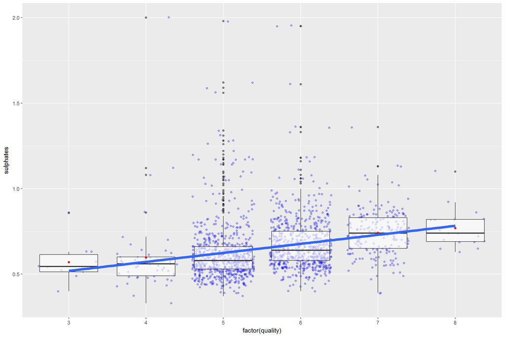

Around the median of 6 for wine quality score and 0.6 for sulphates amount, there is somewhat of a linear relationship in that area. Recall, the correlation between the two variables is 0.251.

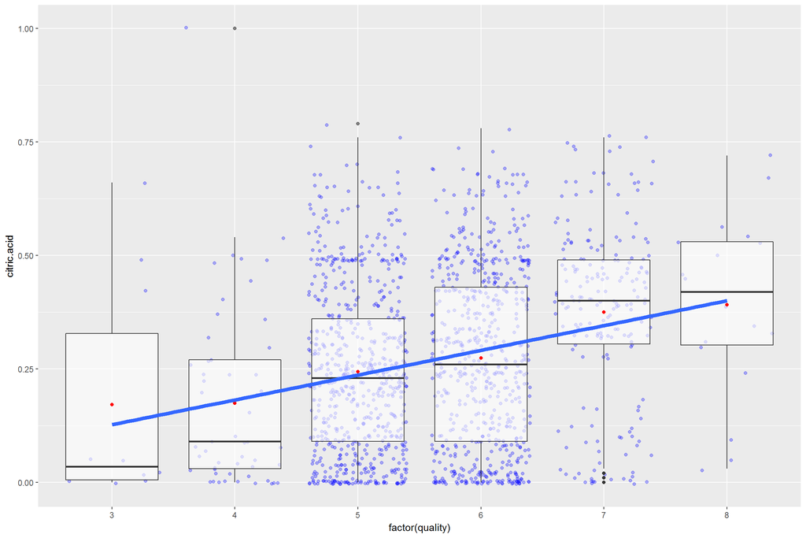

The correlation between citric acid and quality is 0.226 but looking at the graph, we see a slight positive relationship between citric acid and quality.

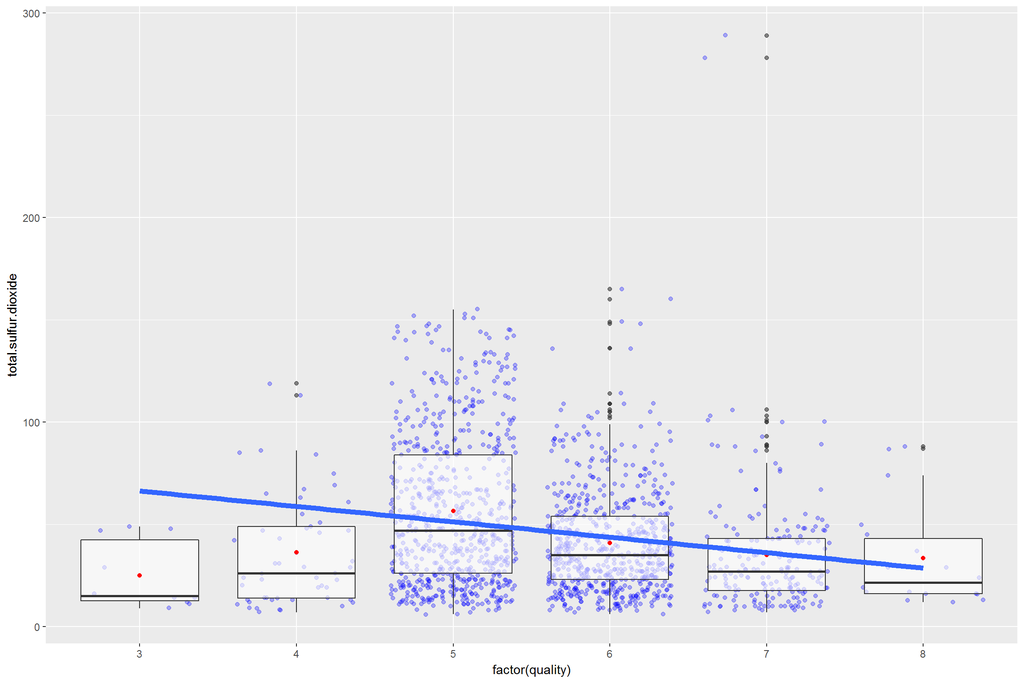

The correlation between total sulfur dioxide and quality is -0.185. Looking at the chart, we see a slight negative relationship between the two.

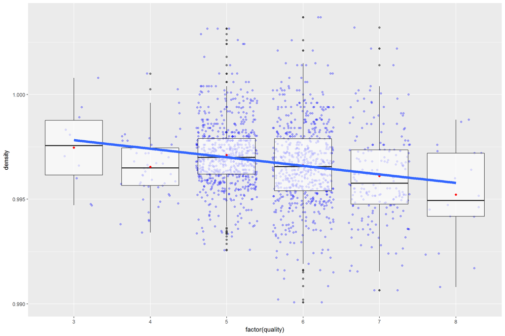

The correlation between density and quality is -0.175. Again, looking at the graph, we see only a slight relationship.

I graphed two of the highest correlations in the correlation matrix. Below, with a correlation of 0.672, there seems to be a somewhat meaningful linear relationship between fixed acidity and citric acid.

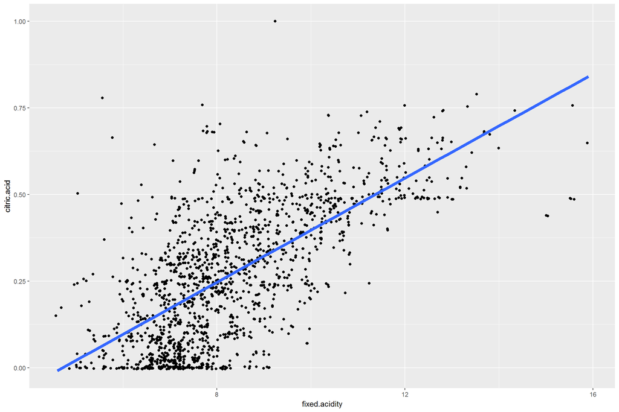

Below with a correlation of -0.683, we see a somewhat moderate negative linear relationship between fixed acidity and pH.

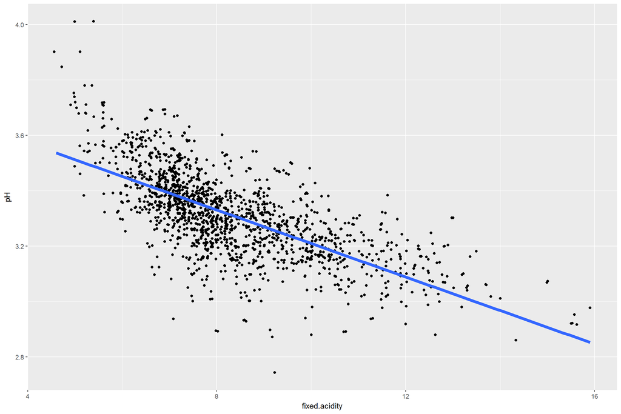

**Relationships observed**

In the plot of alcohol versus quality, between nine and twelve percent alcohol, quality seems to increase.

In the plot of volatile acidity versus quality, between 0.3 and 0.8 volatile acidity, quality seems to decrease.

**Other relationships observed**

In the plots of sulphates and citric acid, both versus quality, there seemed to be a negligible relationship. Both had less then 0.3 correlation.

In the plots of total sulfur dioxide and density, both versus quality, there also seemed to be a negligible relationship. Both had greater then -0.3 correlation.

**Strongest relationship found**

We only saw a moderate correlation with alcohol and wine quality score. The correlation was only 0.476 but it was the highest of all the input variables versus quality in the dataset.

### Multivariate Plots Section

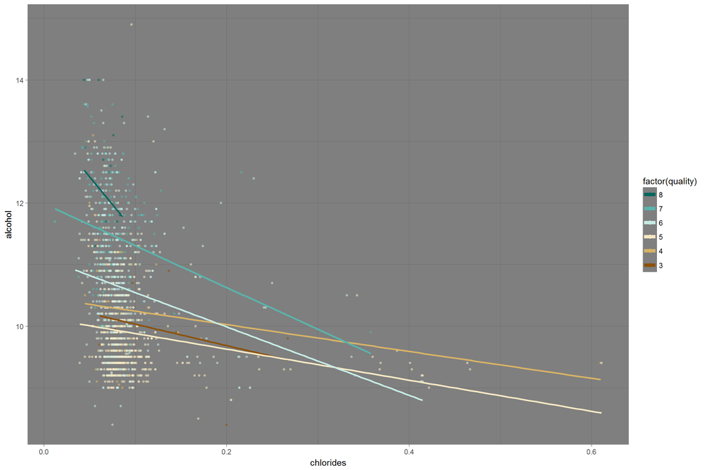

```
##           alcohol quality chlorides
## alcohol     1.000   0.476    -0.221
## quality     0.476   1.000    -0.129
## chlorides  -0.221  -0.129     1.000
```

When adding chlorides to the quality versus alcohol does, we get a different picture. For all the wine quality scores, we see much of the distribution to be 0.0 and 0.15 amount of chlorides. We see a slight negative relationship between chlorides and alcohol by quality.

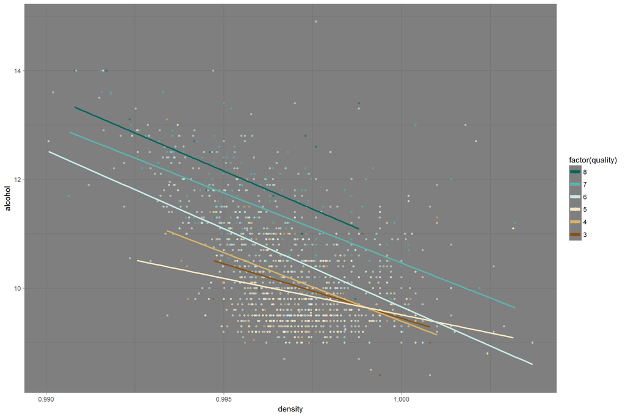

```
##         alcohol quality density
## alcohol   1.000   0.476  -0.496
## quality   0.476   1.000  -0.175
## density  -0.496  -0.175   1.000
```

Adding density to the quality versus alcohol seems to tell a different story. For all the wine quality scores, there seems to be a negative relationship between density and alcohol.

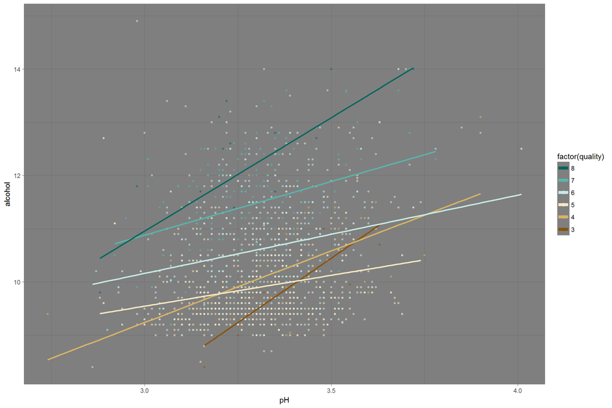

```
##         alcohol quality     pH
## alcohol   1.000   0.476  0.206
## quality   0.476   1.000 -0.058
## pH        0.206  -0.058  1.000
```

When adding pH to the quality versus alcohol, we see a positive linear relationship between pH and alcohol when adding quality.

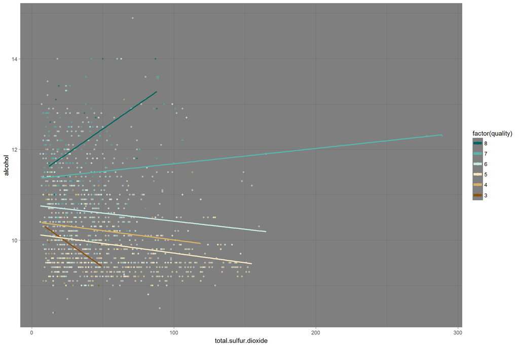

```
##                      alcohol quality total.sulfur.dioxide
## alcohol                1.000   0.476               -0.206
## quality                0.476   1.000               -0.185
## total.sulfur.dioxide  -0.206  -0.185                1.000
```

From this plot, we see higher wine quality scores of 7 or 8, a positive linear relationship between total sulfur dioxide and alcohol. The opposite is true for the lower wine quality scores. We see a downward negative relationship.

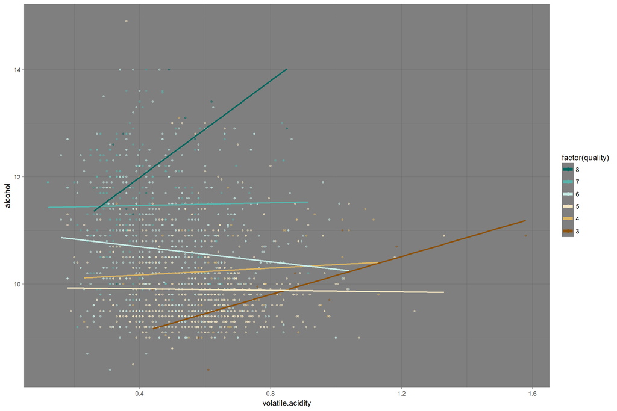

```
##                  alcohol quality volatile.acidity
## alcohol            1.000   0.476           -0.202
## quality            0.476   1.000           -0.391
## volatile.acidity  -0.202  -0.391            1.000
```

For wine quality scores of either 3 or 8, we see a slight positive relationship between volatile acidity and alcohol. There doesn’t appear to be a significant relationship for the other wine quality scores.

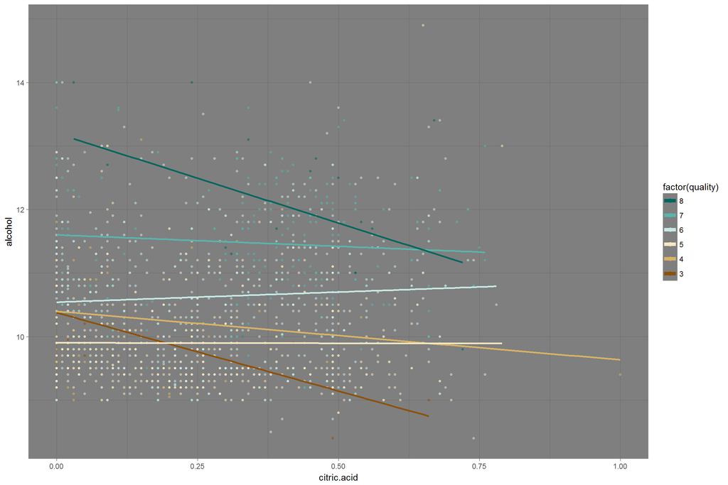

```
##             alcohol quality citric.acid
## alcohol       1.000   0.476       0.110
## quality       0.476   1.000       0.226
## citric.acid   0.110   0.226       1.000
```

Adding citric acid to the quality versus alcohol tells an interesting story. For most of the wine quality scores, as citric acid increases, alcohol appears to decrease a bit. Perhaps, it is standard when adding more citric acid to the wine, the amount of alcohol must be lowered.

### Multivariate Analysis

**Relationships observed**

**Interesting interactions**

When density was added to alcohol versus quality, there seemed to be a slight negative relationship between alcohol and density.